# Another Way of Looking at This

One of the things we notice in the data above is that the two loci with low variability only have a single observation different from the rest and that these differences do not occur in the same individual.

First, let’s construct our genotype matrix: 10 individuals genotyped at ten dominant loci:

```r
mat <- matrix(0, nrow = 10, ncol = 10)
diag(mat) <- 1
mat
```

```
      [,1] [,2] [,3] [,4] [,5] [,6] [,7] [,8] [,9] [,10]
 [1,]    1    0    0    0    0    0    0    0    0     0
 [2,]    0    1    0    0    0    0    0    0    0     0
 [3,]    0    0    1    0    0    0    0    0    0     0
 [4,]    0    0    0    1    0    0    0    0    0     0
 [5,]    0    0    0    0    1    0    0    0    0     0
 [6,]    0    0    0    0    0    1    0    0    0     0
 [7,]    0    0    0    0    0    0    1    0    0     0
 [8,]    0    0    0    0    0    0    0    1    0     0
 [9,]    0    0    0    0    0    0    0    0    1     0
[10,]    0    0    0    0    0    0    0    0    0     1
```

What happens when you calculate the index of association?

```r
IA(apply(mat, 2, dist))
```

```
[1] -1
```

```r
rd(apply(mat, 2, dist))
```

```
[1] -0.1111111
```

Now we have a negative result, but this makes sense because every sample has exactly two loci different between every other sample, making the observed variance zero, so that it doesn’t matter what the denominator is, the result will always be -1.

If you include a genotype that’s dissimilar to all other individuals except for one locus, then the index increases dramatically:

```r
mat2 <- rbind(rep(1, 10), mat)
mat2
```

```
      [,1] [,2] [,3] [,4] [,5] [,6] [,7] [,8] [,9] [,10]
 [1,]    1    1    1    1    1    1    1    1    1     1
 [2,]    1    0    0    0    0    0    0    0    0     0
 [3,]    0    1    0    0    0    0    0    0    0     0
 [4,]    0    0    1    0    0    0    0    0    0     0
 [5,]    0    0    0    1    0    0    0    0    0     0
 [6,]    0    0    0    0    1    0    0    0    0     0
 [7,]    0    0    0    0    0    1    0    0    0     0
 [8,]    0    0    0    0    0    0    1    0    0     0
 [9,]    0    0    0    0    0    0    0    1    0     0
[10,]    0    0    0    0    0    0    0    0    1     0
[11,]    0    0    0    0    0    0    0    0    0     1
```

```r
dmat2 <- apply(mat2, 2, dist)
IA(dmat2)
```

```
[1] 2.310811
```

```r
rd(dmat2)
```

```
[1] 0.2567568
```

If you set the first genotype to be similar to all other individuals except for one locus (think of it as the progenitor), the result is still negative:

```r
mat2[1, ] <- 0
mat2
```

```
      [,1] [,2] [,3] [,4] [,5] [,6] [,7] [,8] [,9] [,10]
 [1,]    0    0    0    0    0    0    0    0    0     0
 [2,]    1    0    0    0    0    0    0    0    0     0
 [3,]    0    1    0    0    0    0    0    0    0     0
 [4,]    0    0    1    0    0    0    0    0    0     0
 [5,]    0    0    0    1    0    0    0    0    0     0
 [6,]    0    0    0    0    1    0    0    0    0     0
 [7,]    0    0    0    0    0    1    0    0    0     0
 [8,]    0    0    0    0    0    0    1    0    0     0
 [9,]    0    0    0    0    0    0    0    1    0     0
[10,]    0    0    0    0    0    0    0    0    1     0
[11,]    0    0    0    0    0    0    0    0    0     1
```

```r
dmat2 <- apply(mat2, 2, dist)
IA(dmat2)
```

```
[1] -0.9
```

```r
rd(dmat2)
```

```
[1] -0.1
```

To illustrate how different these scenarios are, we can construct a minimum spanning network:

```r
mutation_color <- viridis::plasma(10, begin = 1, end = 0)
mat2[1, ] <- 0
x <- df2genind(mat2, type = "PA", sep = "")
mat2[1, ] <- 1
y <- df2genind(mat2, type = "PA", sep = "")
g1 <- poppr.msn(x, diss.dist(x), showplot = FALSE)$graph
g2 <- poppr.msn(y, diss.dist(y), showplot = FALSE)$graph
op <- par(no.readonly = TRUE)
par(mfrow = c(1, 2), mar = c(1, 1, 1, 1))
set.seed(90)
lay <- layout_nicely(g1)
switch_positions <- function(m, x, y){
  tmp    <- m[x, ]
  m[x, ] <- m[y, ]
  m[y, ] <- tmp
  m
}
lay <- lay %>%
  switch_positions(8, 9) %>%
  switch_positions(8, 3) %>%
  switch_positions(7, 3) %>%
  switch_positions(2, 3) %>%
  switch_positions(5, 3) %>%
  switch_positions(6, 4) %>%
  I()
lay[2:11, ] <- lay[11:2, ]
plot(g1,
     vertex.size = 40,
     layout = lay,
     edge.width = 7,
     edge.color = "#404040",
     vertex.label = V(g1)$name,
     vertex.label.font = 2,
     vertex.label.degree = pi/2,
     vertex.color = ifelse(V(g1)$name == "01", mutation_color[1], mutation_color[2]),
     vertex.label.color = "black",
     main = "Negative Index of Assocation")
set.seed(90)
plot(g2,
     vertex.size = 40,
     layout = lay,
     vertex.label = V(g2)$name,
     vertex.label.font = 2,
     vertex.color = ifelse(V(g2)$name == "01", mutation_color[10], mutation_color[2]),
     vertex.label.color = ifelse(V(g2)$name == "01", "white", "black"),
     main = "Positive Index of Assocation")
```

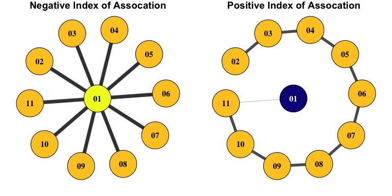

```r
par(op)
```

In the first minimum spanning network, we can see that, even though we have a population with individuals derived from a single progenitor, the index of association is negative, but when we have a population where there is a single, wildly unrelated genotype, the index of association is positive.

## Session Information

```r
options(width = 100)
devtools::session_info()
```

[output not shown]